# hw#2.data624

Sang Yoon (Andy) Hwang

September 9, 2019

# 6.9 Exercises

# 6.9.2. The plastics data set consists of the monthly sales (in thousands) of product A for a plastics manufacturer for five years.

# a. Plot the time series of sales of product A. Can you identify seasonal fluctuations and/or a trend-cycle?

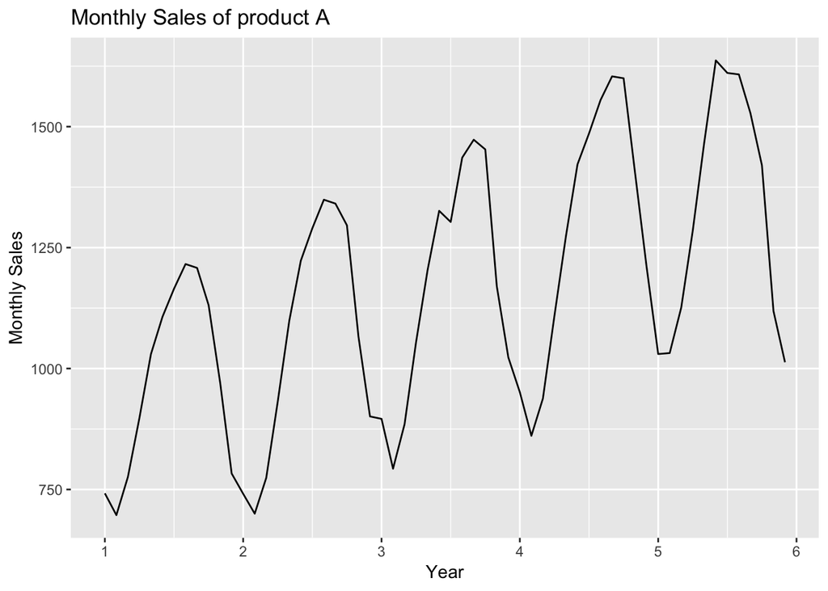

```r
autoplot(plastics) + ggtitle("Monthly Sales of product A") + xlab("Year") + ylab("Monthly Sales")
```

An increasing trend is seen from autoplot - as year goes by, monthly sales for each year seem to be increasing MoM/YoY basis.

# b. Use a classical multiplicative decomposition to calculate the trend-cycle and seasonal indices.

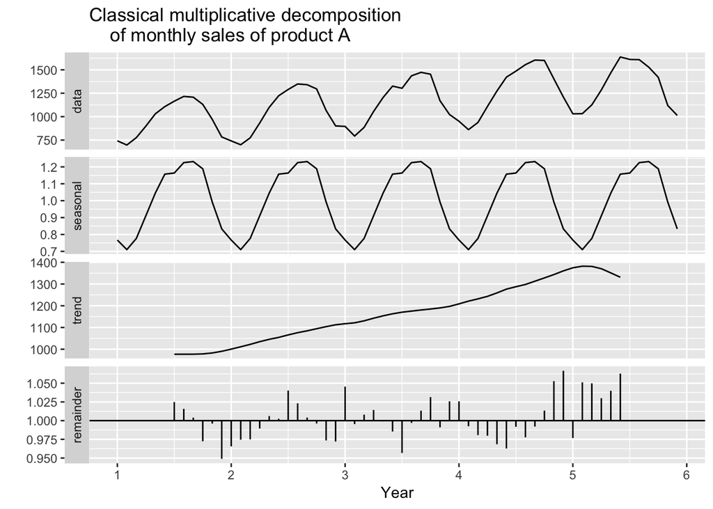

```r
# multiplicative decomposition and seasonality adjusted plot

plastics %>% decompose(type="multiplicative") %>%
  autoplot() + xlab("Year") +
  ggtitle("Classical multiplicative decomposition
    of monthly sales of product A")
```

```r
# calculation of strength of trend-cycle and seasonality.
var_r = var(decompose(plastics,type="multiplicative")$random, na.rm = TRUE)

var_tr = var(decompose(plastics,type="multiplicative")$trend + decompose(plastics,type="multiplicative")$random, na.rm = TRUE)

var_sr = var(decompose(plastics,type="multiplicative")$seasonal + decompose(plastics,type="multiplicative")$random, na.rm = TRUE)

ft = max(0, 1 - var_r / (var_tr))
fs = max(0, 1 - var_r / (var_sr))
ft
```

```
## [1] 0.9999999
```

```r
fs
```

```
## [1] 0.9764368
```

Strength of trend is 0.999 and seasonality is 0.976. Indeed, there are strong trend-cycle and seasonality.

# c. Do the results support the graphical interpretation from part a?

Yes, as we have seen from autoplot result from a, the results in b support strong seasonality and trend-cycle which are seen from the plot in a.

# d. Compute and plot the seasonally adjusted data.

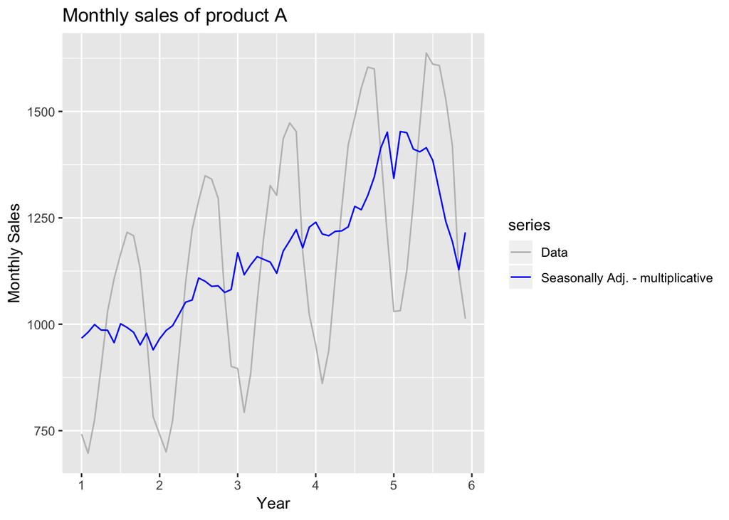

```r
# multiplicative decomposition and seasonality adjusted plot
dcp_m = decompose(plastics,type="multiplicative")
#dcp_add = decompose(plastics)
sadj_m = plastics / dcp_m$seasonal #seasadj(dcp_m)

autoplot(plastics, series = "Data") + autolayer(sadj_m, series = "Seasonally Adj. - multiplicative") + labs(title = "Monthly sales of product A", x = "Year", y = "Monthly Sales") + scale_color_manual(values=c('grey','blue'))
```

Since multiplicative decomposition is used, seasonally adjusted figures are calculated as dividing `plastics` by `dcp_m$seasonal`. As you can see from the above plot, removing seasonality, the series contain only the random component and trend-cycle.

# e. Change one observation to be an outlier (e.g., add 500 to one observation), and recompute the seasonally adjusted data. What is the effect of the outlier?

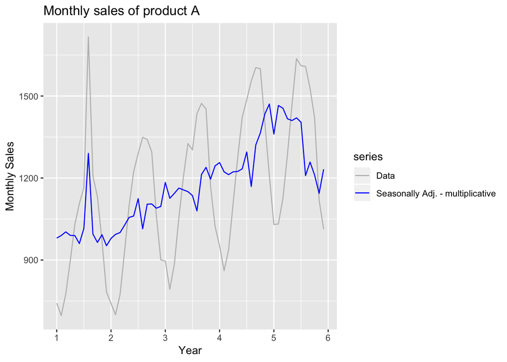

```r
# randomly select index and add 500 to one observation.
plastics_ol <- plastics
#index <- sample(1:length(plastics), 1)
#plastics_ol[index] <- plastics_ol[index] + 500
plastics_ol[8] <- plastics_ol[8] + 500

# multiplicative decomposition and seasonality adjusted plot
dcp_m = decompose(plastics_ol,type="multiplicative")
#dcp_add = decompose(plastics)
sadj_m = plastics_ol / dcp_m$seasonal #seasadj(dcp_m)

autoplot(plastics_ol, series = "Data") + autolayer(sadj_m, series = "Seasonally Adj. - multiplicative") + labs(title = "Monthly sales of product A", x = "Year", y = "Monthly Sales") + scale_color_manual(values=c('grey','blue'))
```

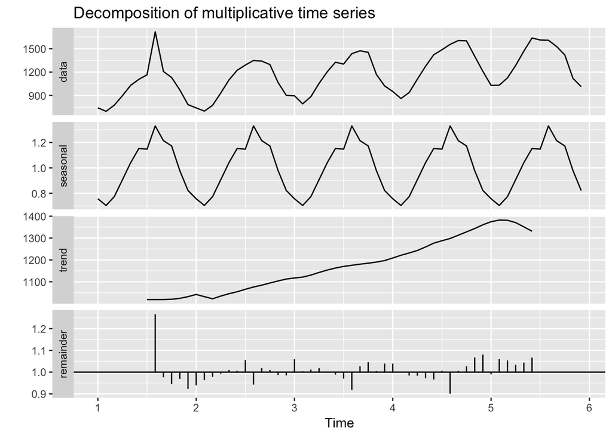

```r
# calculation of strength of trend-cycle and seasonality with outlier
var_r = var(decompose(plastics_ol,type="multiplicative")$random, na.rm = TRUE)

var_tr = var(decompose(plastics_ol,type="multiplicative")$trend + decompose(plastics_ol,type="multiplicative")$random, na.rm = TRUE)

var_sr = var(decompose(plastics_ol,type="multiplicative")$seasonal + decompose(plastics_ol,type="multiplicative")$random, na.rm = TRUE)

ft = max(0, 1 - var_r / (var_tr))

fs = max(0, 1 - var_r / (var_sr))

# decomposition, ft and fs with outlier
autoplot(dcp_m)
```

```r
ft
```

```
## [1] 0.9999998
```

```r
fs
```

```
## [1] 0.9270798
```

From the autoplot, it is apparent that there is a spike in observation 8. Not only that, you can see that one outlier affect the general overall shape of seasonal graph - it is now more “pointy” in every spike. The strength of trend-cycle and seasonality became weaker compared to the case where there was no outlier - with-outlier (random outlier) - 0.9999998 and 0.927, no-outlier - 0.99999999 and 0.9764368.

# f. Does it make any difference if the outlier is near the end rather than in the middle of the time series?

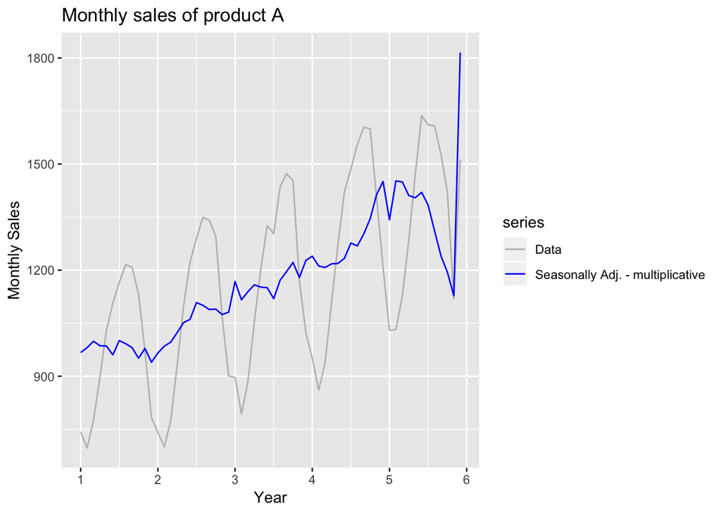

```r
# near the end

# select index near the end and add 500 to one observation.
plastics_ne <- plastics
plastics_ne[max(length(plastics))] <- plastics_ne[max(length(plastics))] + 500

# multiplicative decomposition and seasonality adjusted plot
dcp_m = decompose(plastics_ne,type="multiplicative")
#dcp_add = decompose(plastics)
sadj_m = plastics_ne / dcp_m$seasonal #seasadj(dcp_m)

autoplot(plastics_ne, series = "Data") + autolayer(sadj_m, series = "Seasonally Adj. - multiplicative") + labs(title = "Monthly sales of product A", x = "Year", y = "Monthly Sales") + scale_color_manual(values=c('grey','blue'))
```

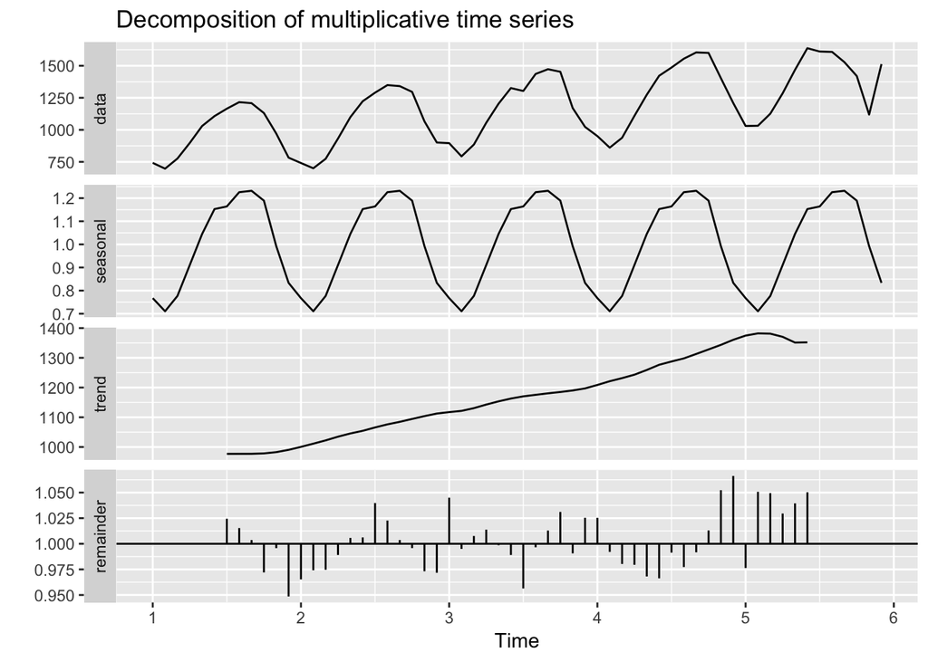

```r
# calculation of strength of trend-cycle and seasonality with outlier
var_r = var(decompose(plastics_ne,type="multiplicative")$random, na.rm = TRUE)

var_tr = var(decompose(plastics_ne,type="multiplicative")$trend + decompose(plastics_ne,type="multiplicative")$random, na.rm = TRUE)

var_sr = var(decompose(plastics_ne,type="multiplicative")$seasonal + decompose(plastics_ne,type="multiplicative")$random, na.rm = TRUE)

ft = max(0, 1 - var_r / (var_tr))
fs = max(0, 1 - var_r / (var_sr))

# decomposition, ft and fs with outlier
autoplot(dcp_m)
```

```r
ft
```

```
## [1] 1
```

```r
fs
```

```
## [1] 0.9773742
```

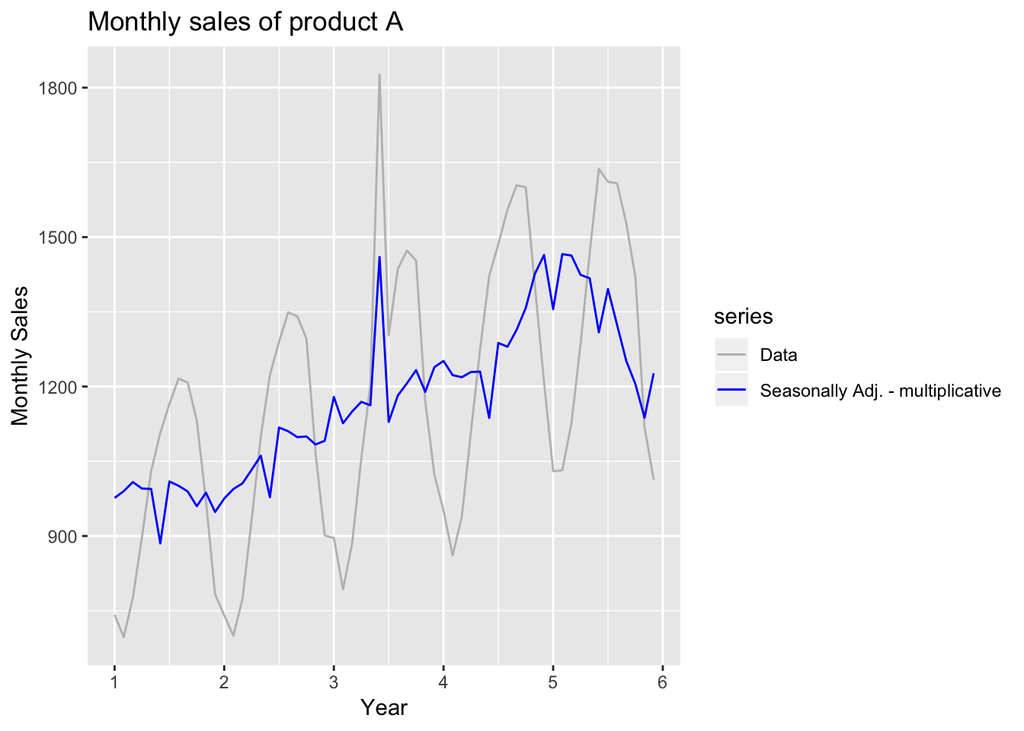

```r
# in the middle

# select index in the middle and add 500 to one observation.
plastics_m <- plastics
plastics_m[(length(plastics) / 2)] <- plastics_m[(length(plastics) / 2)] + 500

# multiplicative decomposition and seasonality adjusted plot
dcp_m = decompose(plastics_m,type="multiplicative")
#dcp_add = decompose(plastics)
sadj_m = plastics_m / dcp_m$seasonal #seasadj(dcp_m)

autoplot(plastics_m, series = "Data") + autolayer(sadj_m, series = "Seasonally Adj. - multiplicative") + labs(title = "Monthly sales of product A", x = "Year", y = "Monthly Sales") + scale_color_manual(values=c('grey','blue'))
```

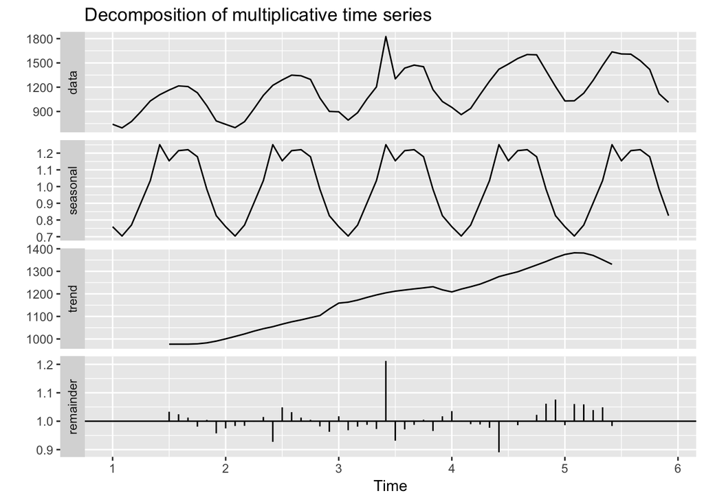

```r
# calculation of strength of trend-cycle and seasonality with outlier
var_r = var(decompose(plastics_m,type="multiplicative")$random, na.rm = TRUE)

var_tr = var(decompose(plastics_m,type="multiplicative")$trend + decompose(plastics_m,type="multiplicative")$random, na.rm = TRUE)

var_sr = var(decompose(plastics_m,type="multiplicative")$seasonal + decompose(plastics_m,type="multiplicative")$random, na.rm = TRUE)

ft = max(0, 1 - var_r / (var_tr))
fs = max(0, 1 - var_r / (var_sr))

# decomposition, ft and fs with outlier
autoplot(dcp_m)
```

```r
ft
```

```
## [1] 0.9999999
```

```r
fs
```

```
## [1] 0.944728
```

Let’s compare the results of strength (trend-cycle and seasonality):

with-outlier (8th index) - 0.9999998 and 0.927

with-outlier (index in the middle) - 0.9999999 and 0.944728

with-outlier (index in the end) - 1 and 0.9773742

no-outlier - 0.99999999 and 0.9764368

From above, we can see that outlier in the end actually improves both trend-cycle and seasonality strength, compared to no-outlier case. When outliers were in random index both trend-cycle and seasonality strength became weaker, compared to no-outlier case. When outliers were in index in the middle, trend-cycle strength was unchanged when seasonality strength became weaker, compared to no-outlier case.

But keep in mind that the improvement (or weakening) is only marginal. Overall, what I can conclude is that the position of outliers does change the strength of both trend-cycle and seasonality and thus, it does marginally change the shapes of trend-cycle and seasonality.